# Gold Mining

Fantasy Football Analytics

Friday, October 31, 2014

The graph below summarises the projections from a variety of sources. This week’s summary includes projections from: Fantasy Football Sharks, CBS’s Jamey Eisenberg, CBS’s Dave Richard, ESPN, Picking Pros, Yahoo Sports, Fox Sports.

## Standard Scoring Leagues

### Week 11 Wide Recievers

From this graph be sure to notice:

- T.Y. Hilton, Golden Tate, Larry Fitzgerald, Pierre Garcon and Eddie Royal have particularly high upsides. For these players, some projections are placing much higher valuations than others. If you need to introduce some uncertainty into your game plan, these may be the players to consider.
- Andre Johnson, Reggie Wayne, Kendall Wright, Doug Baldwin and Dwayne Bowe have little downside to them, which suggests that while their median projection might not be great, there is less uncertainty concerning how poorly they may perform.
- On the other hand, Jordy Nelson, Calvin Johnson, Jeremy Maclin, DeSean Jackson, T.Y. Hilton, Alshon Jeffery, Golden Tate and Brandon Marshall have relatively large downsides this week. If you are planning on starting them, it may be prudent to investigate.

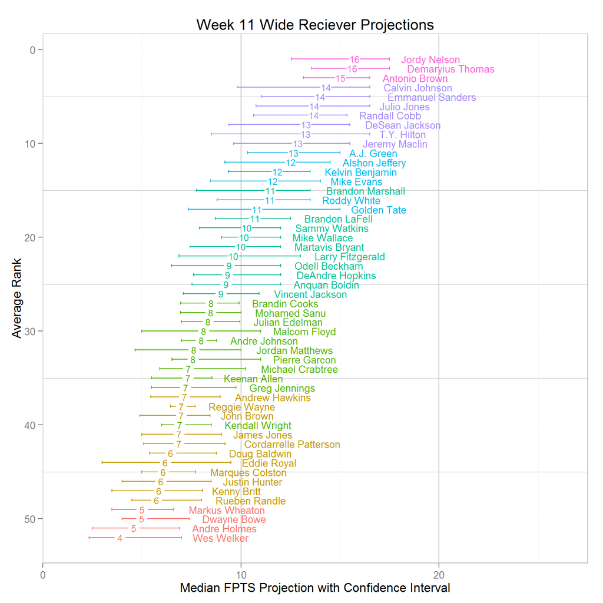

## Top Recievers - Standard Scoring leagues

| name | Lowest Projection | Highest Projection | Mean Projection | Standard Deviation | Median Projection | Average Rank |
| --- | --- | --- | --- | --- | --- | --- |
| Demaryius Thomas | 13.00 | 18.00 | 15.610 | 2.165 | 16.00 | 1.857 |
| Jordy Nelson | 11.40 | 18.00 | 15.440 | 2.286 | 16.00 | 3.857 |
| Antonio Brown | 12.10 | 17.00 | 14.931 | 1.809 | 14.22 | 3.143 |
| Emmanuel Sanders | 10.20 | 17.00 | 13.896 | 2.554 | 14.00 | 6.714 |
| Calvin Johnson | 7.80 | 17.00 | 13.833 | 3.206 | 15.00 | 7.857 |
| Julio Jones | 9.40 | 18.00 | 13.703 | 2.939 | 14.00 | 6.429 |
| Jeremy Maclin | 9.40 | 16.00 | 12.854 | 2.557 | 14.00 | 12.000 |
| DeSean Jackson | 8.47 | 16.00 | 13.053 | 2.767 | 14.00 | 13.857 |
| Randall Cobb | 8.30 | 16.00 | 13.256 | 2.582 | 14.00 | 12.714 |
| T.Y. Hilton | 7.20 | 17.00 | 13.070 | 3.632 | 15.00 | 13.000 |
| A.J. Green | 5.70 | 15.00 | 12.240 | 3.534 | 14.00 | 15.857 |
| Alshon Jeffery | 9.00 | 16.00 | 12.084 | 3.071 | 12.00 | 13.857 |
| Roddy White | 8.70 | 14.00 | 11.404 | 2.127 | 12.00 | 15.286 |
| Kelvin Benjamin | 7.60 | 14.00 | 11.724 | 2.468 | 13.00 | 18.714 |
| Mike Evans | 7.50 | 15.00 | 11.591 | 2.610 | 13.00 | 18.286 |
| Golden Tate | 7.00 | 18.00 | 11.151 | 3.842 | 11.00 | 16.286 |
| Mike Wallace | 9.00 | 13.00 | 10.379 | 1.418 | 10.00 | 21.143 |
| Brandon Marshall | 4.00 | 15.00 | 10.463 | 3.816 | 11.74 | 20.333 |
| Brandon LaFell | 8.40 | 13.00 | 10.685 | 1.919 | 11.00 | 23.667 |
| Sammy Watkins | 7.50 | 13.00 | 10.244 | 2.014 | 10.31 | 23.286 |
| Anquan Boldin | 7.00 | 13.00 | 9.436 | 2.247 | 8.40 | 22.571 |
| Vincent Jackson | 7.00 | 11.85 | 9.021 | 1.787 | 9.00 | 22.714 |
| Julian Edelman | 6.00 | 10.00 | 8.414 | 1.353 | 8.30 | 22.429 |
| Larry Fitzgerald | 5.76 | 14.00 | 9.709 | 3.003 | 9.00 | 23.143 |
| DeAndre Hopkins | 6.60 | 13.00 | 9.560 | 2.244 | 9.00 | 25.000 |
| Martavis Bryant | 6.20 | 13.00 | 10.024 | 2.692 | 11.00 | 32.286 |
| Odell Beckham | 6.00 | 13.00 | 9.309 | 2.794 | 9.46 | 29.286 |
| Brandin Cooks | 6.00 | 11.00 | 8.443 | 2.059 | 8.40 | 26.429 |
| Mohamed Sanu | 6.00 | 11.00 | 8.473 | 1.713 | 8.41 | 31.286 |
| Andre Johnson | 6.00 | 9.57 | 7.778 | 1.198 | 8.00 | 29.167 |

## PPR Leagues

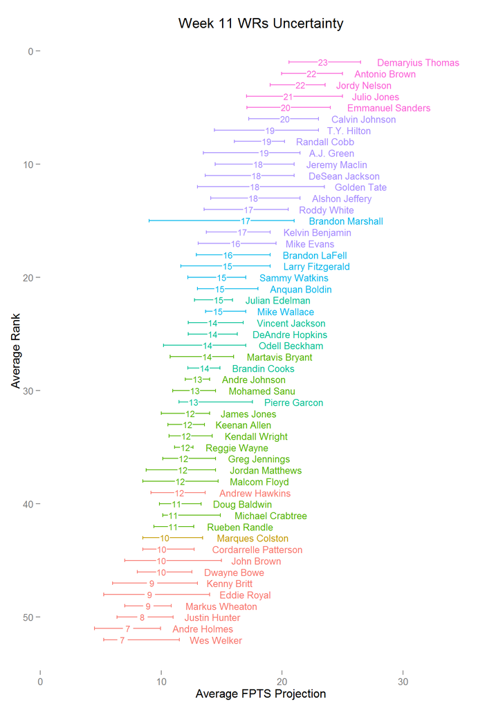

## Top Recievers - PPR leagues

| name | Lowest Projection | Highest Projection | Mean Projection | Standard Deviation | Median Projection | Average Rank |
| --- | --- | --- | --- | --- | --- | --- |
| Demaryius Thomas | 19.10 | 27.00 | 23.38 | 3.294 | 23.00 | 1.857 |
| Antonio Brown | 18.10 | 27.00 | 22.72 | 3.277 | 21.80 | 3.143 |
| Jordy Nelson | 17.00 | 25.00 | 21.41 | 2.534 | 22.00 | 3.857 |
| Julio Jones | 14.80 | 28.00 | 20.69 | 4.213 | 20.00 | 6.429 |
| Emmanuel Sanders | 15.40 | 25.00 | 20.37 | 3.502 | 20.00 | 6.714 |
| Calvin Johnson | 11.50 | 23.00 | 19.79 | 4.229 | 21.00 | 7.857 |
| Jeremy Maclin | 13.40 | 22.00 | 18.07 | 3.304 | 19.00 | 12.000 |
| Randall Cobb | 13.10 | 21.00 | 18.31 | 2.769 | 19.00 | 12.714 |
| T.Y. Hilton | 11.40 | 25.00 | 18.91 | 4.773 | 20.00 | 13.000 |
| Alshon Jeffery | 13.90 | 24.00 | 17.76 | 3.902 | 18.00 | 13.857 |
| DeSean Jackson | 12.37 | 22.00 | 17.74 | 3.318 | 18.00 | 13.857 |
| Roddy White | 13.40 | 21.00 | 17.28 | 3.127 | 17.00 | 15.286 |
| A.J. Green | 8.00 | 22.00 | 17.54 | 5.069 | 19.00 | 15.857 |
| Golden Tate | 12.76 | 28.00 | 18.17 | 5.488 | 18.00 | 16.286 |
| Mike Evans | 12.20 | 21.00 | 16.49 | 3.079 | 18.00 | 18.286 |
| Kelvin Benjamin | 12.00 | 20.00 | 16.55 | 3.110 | 17.00 | 18.714 |
| Brandon Marshall | 9.00 | 21.00 | 16.05 | 4.295 | 16.99 | 20.333 |
| Mike Wallace | 13.35 | 19.00 | 15.08 | 1.936 | 14.40 | 21.143 |
| Julian Edelman | 12.00 | 16.00 | 14.54 | 1.395 | 15.00 | 22.429 |
| Anquan Boldin | 12.95 | 20.00 | 15.16 | 2.788 | 14.00 | 22.571 |
| Vincent Jackson | 11.50 | 17.55 | 14.36 | 2.089 | 14.00 | 22.714 |
| Sammy Watkins | 11.90 | 18.00 | 14.94 | 2.334 | 15.51 | 23.286 |
| Larry Fitzgerald | 10.26 | 20.00 | 15.31 | 3.525 | 16.00 | 23.143 |
| Brandon LaFell | 12.90 | 19.00 | 15.47 | 2.386 | 15.50 | 23.667 |
| DeAndre Hopkins | 10.50 | 18.00 | 14.49 | 2.720 | 14.00 | 25.000 |
| Brandin Cooks | 11.00 | 16.00 | 13.67 | 1.864 | 13.60 | 26.429 |
| Odell Beckham | 8.40 | 19.00 | 13.79 | 3.603 | 13.96 | 29.286 |
| Andre Johnson | 11.00 | 14.97 | 13.11 | 1.334 | 13.00 | 29.167 |
| Pierre Garcon | 10.96 | 22.00 | 13.77 | 3.709 | 13.00 | 30.286 |
| Keenan Allen | 10.00 | 14.00 | 12.25 | 1.528 | 13.00 | 30.714 |